# Population Genetics - Assignment One

Task 1: Interpretation of the genetic pattern of threespine stickleback - Analyse the genetic diversity of all stickleback populations, separately and hierarchically, and interpret the data. A question you might ask is: why are they so different? - Analyse the genetic divergence between and among the coastal and inland samples, and interpret the data. A question you might ask is: why are they so different?

Loading packages.

```r
library(adegenet)
library(hierfstat)
library(genetics)
library(pegas)
```

Reading in the data.

```r
data <- read.genepop('/home/james/Documents/leuven/second-year/Evolutionary-and-Quantitative-Genetics/part-two/first-assignment/data/stickle.gen')
```

```
 Converting data from a Genepop .gen file to a genind object...


File description:  Microsatellite genotypes of threespined stickleback
```

```
Duplicate individual names detected. Coercing them to be unique.
```

```
...done.
```

# Calculating Genetic Variation

Adegenet contains a number of functions to analyse genetic variation.

Estimate expected heterozygosity.

```r
exp_het <- Hs(data)
```

Obtain the number of alleles per population.

```r
sum <- summary(data)
nall <- sum$pop.n.all
```

Visualize the results

```r
pdf(file = "/home/james/Documents/leuven/second-year/Evolutionary-and-Quantitative-Genetics/part-two/first-assignment/het.pdf")
barplot(exp_het, xlab = 'Population', ylab = 'Heterozygosity')
dev.off()
```

```r
pdf(file = "/home/james/Documents/leuven/second-year/Evolutionary-and-Quantitative-Genetics/part-two/first-assignment/nall.pdf")
```

```r
barplot(nall, xlab = 'Population', ylab = 'Number of alleles')
dev.off()
```

What do you notice? - Populations 5, 6 and 7 have less heterozygosity that populations 1 to 4. - Populations 5, 6 and 7 also have fewer alleles than populations 1 to 4.

How do you interpret these histograms? My interpretation is that due to the reduced number of alleles in populations 5, 6 and 7, there is naturally going to be less heterozygosity in these populations, simply due to the fact that there are more heterozygous combinations of alleles relative to homozygous combinations.

Heterozygosity ratio test.

```r
calc.ratio <- function(n) {
   ratio.vector = c()
   for (i in 5:n) {
   ratio = (choose(i, 2) - i)/i
   print(i)
   ratio.vector[i-4] <- ratio
   }
   return(ratio.vector)
}

calc.ratio
```

```
function(n) {
   ratio.vector = c()
   for (i in 5:n) {
   ratio = (choose(i, 2) - i)/i
   print(i)
   ratio.vector[i-4] <- ratio
   }
   return(ratio.vector)
}
```

```r
ratio.vector = calc.ratio(50)
```

```
[1] 5
[1] 6
[1] 7
[1] 8
[1] 9
[1] 10
[1] 11
[1] 12
[1] 13
[1] 14
[1] 15
[1] 16
[1] 17
[1] 18
[1] 19
```

[output cut: 31 more lines]

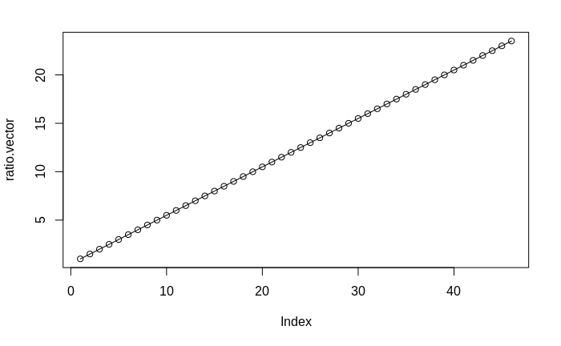

```r
plot(ratio.vector, type='ol')
```

Read in stickle.dat file.

```r
data1 <- read.fstat('/home/james/Documents/leuven/second-year/Evolutionary-and-Quantitative-Genetics/part-two/first-assignment/data/stickle.dat')
```

```
Read 4 items
Read 5 items
Read 2070 items
```

Estimate the allelic richness. Allelic richness (number of alleles) is a measure of genetic diversity indicative of a population’s long-term potential for adaptability and persistence. Discuss rarefaction.

```r
AR <- allelic.richness(data1)
AR
```

```
$min.all
[1] 76

$Ar
```

|  | 1 | 2 | 3 | 4 | 5 | 6 | 7 |
| --- | --- | --- | --- | --- | --- | --- | --- |
| Gac4b | 8.987766 | 8.985825 | 10.267346 | 10.27568 | 4.000000 | 3.987483 | 8.722471 |
| Gac7b | 10.981323 | 13.655003 | 8.678238 | 14.37932 | 6.224242 | 5.734966 | 4.939249 |
| Gac14b | 2.977278 | 3.931725 | 3.759887 | 4.00000 | 2.944242 | 1.000000 | 1.000000 |
| Gac9b | 14.921745 | 15.716816 | 11.898100 | 14.00000 | 4.997290 | 9.024752 | 3.704242 |
| Gac10b | 27.249070 | 20.389009 | 27.570134 | 28.74059 | 11.619014 | 21.193845 | 12.517687 |

```
NA
```

Estimate the mean allelic richness over all loci per population

```r
meanAR <- colMeans(AR$Ar)
meanAR
```

```
        1         2         3         4         5         6         7
13.023436 12.535676 12.434741 14.279119  5.956958  8.188209  6.176730
```

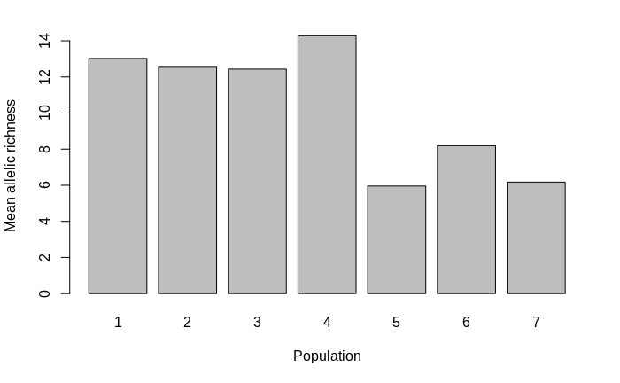

```r
barplot(meanAR, xlab = 'Population' , ylab = 'Mean allelic richness')
```

# Calculating Genetic Structure

First, let’s assess the pairwise genetic differentiation as estimated with FST. Talk a bit about fixation index. Interpret the results below.

```r
pp <- pairwise.neifst(data1)
pp
```

```
       1      2      3      4      5      6      7
1     NA 0.0177 0.0272 0.0638 0.1155 0.1077 0.1800
2 0.0177     NA 0.0374 0.0751 0.1231 0.1229 0.1715
3 0.0272 0.0374     NA 0.0709 0.1486 0.1650 0.2226
4 0.0638 0.0751 0.0709     NA 0.1745 0.1877 0.2480
5 0.1155 0.1231 0.1486 0.1745     NA 0.1977 0.2889
6 0.1077 0.1229 0.1650 0.1877 0.1977     NA 0.2774
7 0.1800 0.1715 0.2226 0.2480 0.2889 0.2774     NA
```

Let’s now assess the variability between populations using a Discriminant Analysis of Principal Components (DAPC). DAPC is a method that describes the diversity between pre-defined groups; it optimizes the variability between groups while minimizing the variability within groups. This is fundamentally different than for instance the Principal Component Analysis (PCA), which describes the global diversity, possibly overlooking differences between groups. Define 40 PCAs and 5 discriminant functions. Interpret the results below.

```r
dapcstickle <- dapc(data, n.pca = 40, n.da = 5)
dapcstickle
```

```
    #################################################
    # Discriminant Analysis of Principal Components #
    #################################################
class: dapc
$call: dapc.genind(x = data, n.pca = 40, n.da = 5)

$n.pca: 40 first PCs of PCA used
$n.da: 5 discriminant functions saved
$var (proportion of conserved variance): 0.887

$eig (eigenvalues): 583.5 288.8 144.8 83.31 35.02 ...

  vector    length content
1 $eig      6      eigenvalues
2 $grp      345    prior group assignment
3 $prior    7      prior group probabilities
4 $assign   345    posterior group assignment
5 $pca.cent 102    centring vector of PCA
6 $pca.norm 102    scaling vector of PCA
7 $pca.eig  97     eigenvalues of PCA

  data.frame    nrow ncol content
1 $tab          345  40   retained PCs of PCA
2 $means        7    40   group means
3 $loadings     40   5    loadings of variables
4 $ind.coord    345  5    coordinates of individuals (principal components)
5 $grp.coord    7    5    coordinates of groups
6 $posterior    345  7    posterior membership probabilities
7 $pca.loadings 102  40   PCA loadings of original variables
8 $var.contr    102  5    contribution of original variables
```

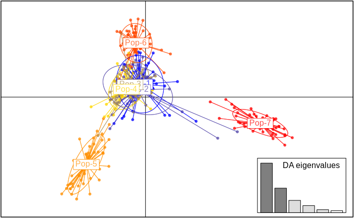

```r
# pdf(file = "/home/james/Documents/leuven/second-year/Evolutionary-and-Quantitative-Genetics/part-two/first-assignment/dapc.pdf")
scatter(dapcstickle)
```

```r
# dev.off()
```

DAPC in itself requires prior groups to be defined. However, groups are often unknown or uncertain, so we need to identify genetic clusters. Here we will use a genetic clustering approach in R. The function find.clusters is an algorithm that performs k-means clustering during which it tries to find a given number k of groups maximizing the variation between these groups. To identify the optimal number of clusters, k-means is run sequentially with increasing values of k, and different clustering solutions are compared using Bayesian Information Criterion (BIC). Ideally, the optimal clustering solution should correspond to the lowest BIC. In practice, the ’best’ BIC is often indicated by an elbow in the curve of BIC values as a function of k.

```r
pdf(file = "/home/james/Documents/leuven/second-year/Evolutionary-and-Quantitative-Genetics/part-two/first-assignment/cluster.pdf")
clust <- find.clusters(data, n.pca = 100)
```

```
Choose the number of clusters (>=2):
```

```r
7
dev.off()
```

See which clusters individuals are assigned to.

```r
as.data.frame(clust$grp)
```

|  | clust$grp |
| --- | --- |
| 001 | 6 |
| 002 | 6 |
| 003 | 2 |
| 004 | 2 |
| 005 | 6 |
| 006 | 2 |
| 007 | 7 |
| 008 | 7 |
| 009 | 6 |
| 010 | 5 |

[output cut: 335 more lines]

We create a table that shows the number of individuals for a certain population assigned to a certain cluster.

```r
table(clust$grp, data$pop)
```

```
    Pop-1 Pop-2 Pop-3 Pop-4 Pop-5 Pop-6 Pop-7
  1     0     1     0    24     0     0     0
  2     7     5     4     5     4    25     1
  3     0     2     0     0     0     0    45
  4     2     1     1     1     0    20     0
  5     3     1     0     0    42     0     0
  6    15    19    11     9     3     5     4
  7    22    21    34     7     1     0     0
```

Visualising the table.

```r
pdf(file = "/home/james/Documents/leuven/second-year/Evolutionary-and-Quantitative-Genetics/part-two/first-assignment/table.pdf")
table.value(table(clust$grp,data$pop))
```

What do you notice here and how do you interpret this?